# Fusa: Blup and heritability

# 1/ Introduction

This file is a supplementary data attached with the publication.  
It describes the analysis of the phenotypic data. These data are organized experiment per experiment (distinct files). There are 7 experiments, in different places and year.

This RMD file allows to:  
- **charge** every phenotypic files  
- compute **blups** for each trait - compute **heritability** for each trait  
- **merge** all experiments together  
- put **explicit names** to variable  
- output a **summary file** is made

We need a few **libraries**

```r
library(rmdformats)
library(xtable)
library(gdata)
library(lme4)
library(RColorBrewer)
my_colors=brewer.pal(8, "Set2")
```

Let’s **upload** every file

```r
# Watch out, to reproduct analysis, you have to update the path.
my_path="/Users/yan/Dropbox/Publi_Fusariose/ANALYSIS_REPRO/DATA/PHENOTYPE"
setwd(my_path)
# Cappelles
CAP13=read.xls("Cappelle_2013_données élaborées.xlsx", sheet = 5, header = TRUE, na.strings="NA")
# Grisolles
GRI11=read.xls("Grisolles_2011_données élaborées.xlsx", sheet = 1, header = TRUE, na.strings="NA")
GRI13=read.xls("Grisolles_2013_données élaborées.xlsx", sheet = 3, header = TRUE)
GRI15=read.xls("Grisolles_2015_données élaborées.xlsx", sheet = 3, header = TRUE)
#Lectoure
LEC14=read.xls("Lectoure_2014_données élaborées.xlsx", sheet = 3, header = TRUE)
# Montbequi
BEQ11=read.xls("Monbequi_2011_données élaborées.xlsx", sheet = 2, header = TRUE)
# Montbartier
BAR14=read.xls("Montbartier_2014_données élaborées.xlsx", sheet = 2, header = TRUE)
# DON
CAP13_DON=read.xls("DON données élaborées.xlsx", sheet = 1, header = TRUE)
GRI13_DON=read.xls("DON données élaborées.xlsx", sheet = 2, header = TRUE)
LEC14_DON=read.xls("DON données élaborées.xlsx", sheet = 3, header = TRUE)
# All individuals that exist for this pop:
my_indiv=read.table("all_dic2_Silur.txt", header=F)[,1]
my_indiv=c("dic2","silur",as.character(my_indiv) )
```

# 2/ Useful Functions

**HERITABILITY**  
Without any effect in the model

```r
calculate_herit=function(my_col, my_data){

  # Combien de rep2?
  r2=nrow(my_data[ which(my_data$rep==2 & !is.na(my_data[,my_col])), ])

  # si 0, alors je retourne NA pour l'hérit:
  if(r2==0){ return("NA") ; continue }

  #Calcul hérit
  aov<- lmer ( my_data[,my_col] ~ (1|geno)  , data=my_data)
  VL<-as.numeric(VarCorr(aov)$geno)
  VRes<-as.numeric(attr(VarCorr(aov),"sc"))^2
  hdeux=round(VL/(VL + VRes) , 6)
  return(hdeux)
}
```

With **inoculation date** in the model

```r
calculate_herit_ino=function(my_col, my_data, my_ino){

  # Combien de rep2?
  r2=nrow(my_data[ which(my_data$rep==2 & !is.na(my_data[,my_col])), ])

  # si 0, alors je retourne NA pour l'hérit:
  if(r2==0){ return("NA") ; continue }

  #Calcul hérit
  aov<- lmer ( my_data[,my_col] ~ (1|geno) + my_data[,my_ino]  , data=my_data)
  VL<-as.numeric(VarCorr(aov)$geno)
  VRes<-as.numeric(attr(VarCorr(aov),"sc"))^2
  hdeux=round(VL/(VL + VRes) , 6)
  return(hdeux)
}
```

**BLUPS**  
No cofactor in the model

```r
calculate_blup_nocofactor=function(my_col, my_data){
  aov<- lmer ( my_data[,my_col] ~ (1|geno)   , data=my_data)
  blup <- ranef(aov, condVar = TRUE)
  tmp=data.frame(rownames(blup$geno), blup$geno[,1])
  colnames(tmp)[2]=paste( colnames(my_data)[my_col], "blup", sep="_")
  return(tmp)
  }
```

With **innoculation date**

```r
calculate_blup=function(my_col, my_ino, my_data){
  aov<- lmer ( my_data[,my_col] ~ (1|geno) + my_data[,my_ino]  , data=my_data)
  blup <- ranef(aov, condVar = TRUE)
  tmp=data.frame(rownames(blup$geno), blup$geno[,1])
  colnames(tmp)[2]=paste( colnames(my_data)[my_col], "blup", sep="_")
  return(tmp)
  }
```

With **height**

```r
calculate_blup_heightONLY=function(my_col,  my_height, my_data){
  aov<- lmer ( my_data[,my_col] ~ (1|geno) + my_data[,my_height]  , data=my_data)
  blup <- ranef(aov, condVar = TRUE)
  tmp=data.frame(rownames(blup$geno), blup$geno[,1])
  colnames(tmp)[2]=paste( colnames(my_data)[my_col], "blup", sep="_")
  return(tmp)
  }
```

With **innoculation** date AND **height** into account

```r
calculate_blup_height=function(my_col, my_ino, my_height, my_data){
  aov<- lmer ( my_data[,my_col] ~ (1|geno) + my_data[,my_ino] + my_data[,my_height]  , data=my_data)
  blup <- ranef(aov, condVar = TRUE)
  tmp=data.frame(rownames(blup$geno), blup$geno[,1])
  colnames(tmp)[2]=paste( colnames(my_data)[my_col], "blup", sep="_")
  return(tmp)
  }
```

# 3/ Fusa

## Cappelle 2013

Give better column names to the dataset & clean data

```r
# Rename columns:
my_names=c("geno", "rep", "CAP13_EPI", "CAP13_FLO", "CAP13_HEI", "CAP13_VER", "CAP13_INO", "CAP13_INO2", "CAP13_PEPI300", "CAP13_PEPI400", "CAP13_PEPI550", "CAP13_PEPIAUDPC", "CAP13_NEPIL300", "CAP13_NEPIL400", "CAP13_NEPIL550", "CAP13_NEPILAUDPC", "CAP13_PEPIL300", "CAP13_PEPIL400", "CAP13_PEPIL550", "CAP13_PEPILAUDPC")
colnames(CAP13)=my_names
CAP13$geno=gsub("TT06DC ", "TT06DC.", CAP13$geno)
# Delete the rep2 of PEPI400, NEPIL400 et PEPIL400 which are wrong
CAP13$CAP13_PEPI400[CAP13$rep=="2"]=NA
CAP13$CAP13_NEPIL400[CAP13$rep=="2"]=NA
CAP13$CAP13_PEPIL400[CAP13$rep=="2"]=NA
```

Let’s calculate and print heritabilities (with and without inoc date effect):

```r
# Calcul héritabilité:
herit_CAP13=matrix(0,2,ncol(CAP13)-2)
colnames(herit_CAP13)=my_names[3:length(my_names)]
num=0
for(i in c(3:ncol(CAP13))){
  num=num+1
  a=calculate_herit(i, CAP13)
  b=calculate_herit_ino(i, CAP13, 7)
  herit_CAP13[ ,num]=c(a,b)
}
herit_CAP13=apply(herit_CAP13 , 2 , as.numeric)
```

| CAP13_EPI | CAP13_FLO | CAP13_HEI | CAP13_VER | CAP13_INO | CAP13_INO2 | CAP13_PEPI300 | CAP13_PEPI400 | CAP13_PEPI550 | CAP13_PEPIAUDPC | CAP13_NEPIL300 | CAP13_NEPIL400 | CAP13_NEPIL550 | CAP13_NEPILAUDPC | CAP13_PEPIL300 | CAP13_PEPIL400 | CAP13_PEPIL550 | CAP13_PEPILAUDPC |
| --- | --- | --- | --- | --- | --- | --- | --- | --- | --- | --- | --- | --- | --- | --- | --- | --- | --- |
| 0.79 | 0.73 | 0.85 | 0.68 | 0.79 | 0.82 | 0.48 |  | 0.49 | 0.49 | 0.47 |  | 0.61 | 0.64 | 0.49 |  | 0.57 | 0.66 |
| 0.55 | 0.36 | 0.85 | 0.68 | 0.89 | 0.36 | 0.43 |  | 0.44 | 0.42 | 0.45 |  | 0.50 | 0.57 | 0.48 |  | 0.46 | 0.61 |

Change the format of the data: distincts columns for rep1 and rep2 (one line per genotype)

```r
a=CAP13[CAP13$rep==1 , c(-2)]
colnames(a)[2:ncol(a)]=paste( my_names[3:length(my_names)], "rep1", sep="_" )
b=CAP13[CAP13$rep==2 , c(-2)]
colnames(b)[2:ncol(b)]=paste( my_names[3:length(my_names)], "rep2", sep="_" )
CAP13_clean=merge(a, b, by.x=1, by.y=1 , all=T)
CAP13_clean=CAP13_clean[ , -which(colnames(CAP13_clean)%in%c("CAP13_PEPI400_rep2","CAP13_NEPIL400_rep2","CAP13_PEPIL400_rep2"))]
```

Then we have to calculate the BLUP of every genotype for every variable and add it to the “clean” table :

```r
for(i in c(3:ncol(CAP13))){

  # Cas particulier pour  les 400
  if( i %in% which(colnames(CAP13)%in%c("CAP13_PEPI400","CAP13_NEPIL400","CAP13_PEPIL400"))){
    tmp=aggregate( CAP13[,i], by=list(CAP13[,1]) , mean, na.rm=T)
    colnames(tmp)[2]=paste(colnames(CAP13)[i],"_blup",sep="")
  }else{
    tmp=calculate_blup_height(i, 7, 5, CAP13)
  }

  CAP13_clean=merge(CAP13_clean , tmp, by.x=1, by.y=1, all.x=T)
  }
```

## Grisolles 2011

Give better column names to the dataset

```r
# Rename columns:
my_names=c("geno", "rep", "GRI11_HEI", "GRI11_EPI", "GRI11_NOT300", "GRI11_NOT350", "GRI11_NOT450", "GRI11_NOT500", "GRI11_NOT550", "GRI11_NOTAUDPC", "GRI11_NEPIL300", "GRI11_NEPIL350", "GRI11_NEPIL450", "GRI11_NEPIL500", "GRI11_NEPIL550", "GRI11_NEPILAUDPC", "GRI11_NANT" )
colnames(GRI11)=my_names
GRI11$geno=gsub("TT06DC ", "TT06DC.", GRI11$geno)
GRI11$geno=gsub("DIC2", "dic2", GRI11$geno)
GRI11$geno=gsub("Silur", "silur", GRI11$geno)
```

Let’s calculate and print heritabilities. No innoculation date provided so heritability is calculated only once.

```r
# Calcul héritabilité:
herit_GRI11=matrix(0,1,ncol(GRI11)-2)
colnames(herit_GRI11)=my_names[3:length(my_names)]
num=0
for(i in c(3:ncol(GRI11))){
  num=num+1
  a=calculate_herit(i, GRI11)
  herit_GRI11[1,num]=a
  }
```

| GRI11_HEI | GRI11_EPI | GRI11_NOT300 | GRI11_NOT350 | GRI11_NOT450 | GRI11_NOT500 | GRI11_NOT550 | GRI11_NOTAUDPC | GRI11_NEPIL300 | GRI11_NEPIL350 | GRI11_NEPIL450 | GRI11_NEPIL500 | GRI11_NEPIL550 | GRI11_NEPILAUDPC | GRI11_NANT |
| --- | --- | --- | --- | --- | --- | --- | --- | --- | --- | --- | --- | --- | --- | --- |
| NA | 0.254154 | 0.154995 | 0.176831 | 0.237493 | 0.217175 | 0.185623 | 0.26935 | 0.106879 | 0.089302 | 0.098564 | 0.127013 | 0.212703 | 0.171407 | NA |

To finish, we change the format of the data: distincts columns for rep1 and rep2

```r
a=GRI11[GRI11$rep==1 , c(-2)]
colnames(a)[2:ncol(a)]=paste( my_names[3:length(my_names)], "rep1", sep="_" )
b=GRI11[GRI11$rep==2 , c(-2)]
colnames(b)[2:ncol(b)]=paste( my_names[3:length(my_names)], "rep2", sep="_" )
GRI11_clean=merge(a, b, by.x=1, by.y=1 , all=T)
```

Then we have to calculate the BLUP of every genotype for every variable and add it to the “clean” table. Since there is no height provided here, we duplicate the height of rep1

```r
# Duplicate height of rep1.
aaa=aggregate(GRI11$GRI11_HEI , by=list(GRI11$geno) , mean, na.rm=T)
GRI11=merge(GRI11, aaa, by.x=1 , by.y=1, all.x=T)
GRI11$GRI11_HEI=GRI11$x
GRI11=GRI11[ , -ncol(GRI11)]
# Calcultate blup
for(i in c(4: (ncol(GRI11)-1) )){
  tmp=calculate_blup_heightONLY(i, 3, GRI11)
  GRI11_clean=merge(GRI11_clean , tmp, by.x=1, by.y=1, all.x=T)
  }
```

## Grisolles 2013

Give better column names to the dataset

```r
# Rename columns:
GRI13=GRI13[,c(-2,-12)]
my_names=c("geno", "rep", "GRI13_EPI", "GRI13_FLO", "GRI13_HEI", "GRI13_INO", "GRI13_PEPI350", "GRI13_PEPI450", "GRI13_PEPI550", "GRI13_PEPIAUDPC", "GRI13_NEPIL350", "GRI13_NEPIL450", "GRI13_NEPIL550", "GRI13_NEPILAUDPC", "GRI13_PEPIL350","GRI13_PEPIL450","GRI13_PEPIL550","GRI13_PEPILAUDPC",   "GRI13_NOT350", "GRI13_NOT450", "GRI13_NOT550", "GRI13_NOTAUDPC")
colnames(GRI13)=my_names
GRI13$geno=gsub("TT06DC ", "TT06DC.", GRI13$geno)
```

Let’s calculate and print heritabilities:

```r
# Calcul héritabilité:
herit_GRI13=matrix(0,2,ncol(GRI13)-2)
colnames(herit_GRI13)=my_names[3:length(my_names)]
num=0
for(i in c(3:ncol(GRI13))){
  num=num+1
  a=calculate_herit(i, GRI13)
  b=calculate_herit_ino(i, GRI13, 6)
  herit_GRI13[ ,num]=c(a,b)
  }
```

| GRI13_EPI | GRI13_FLO | GRI13_HEI | GRI13_INO | GRI13_PEPI350 | GRI13_PEPI450 | GRI13_PEPI550 | GRI13_PEPIAUDPC | GRI13_NEPIL350 | GRI13_NEPIL450 | GRI13_NEPIL550 | GRI13_NEPILAUDPC | GRI13_PEPIL350 | GRI13_PEPIL450 | GRI13_PEPIL550 | GRI13_PEPILAUDPC | GRI13_NOT350 | GRI13_NOT450 | GRI13_NOT550 | GRI13_NOTAUDPC |
| --- | --- | --- | --- | --- | --- | --- | --- | --- | --- | --- | --- | --- | --- | --- | --- | --- | --- | --- | --- |
| 0.89 | 0.75 | 0.89 | 0.80 | 0.34 | 0.22 | 0.33 | 0.36 | 0.53 | 0.33 | 0.60 | 0.52 | 0.51 | 0.32 | 0.59 | 0.47 | 0.36 | 0.32 | 0.47 | 0.41 |
| 0.69 | 0.20 | 0.90 | 0.85 | 0.32 | 0.18 | 0.32 | 0.33 | 0.54 | 0.33 | 0.60 | 0.52 | 0.51 | 0.32 | 0.59 | 0.47 | 0.34 | 0.32 | 0.48 | 0.40 |

To finish, we change the format of the data: distincts columns for rep1 and rep2

```r
a=GRI13[GRI13$rep==1 , c(-2)]
colnames(a)[2:ncol(a)]=paste( my_names[3:length(my_names)], "rep1", sep="_" )
b=GRI13[GRI13$rep==2 , c(-2)]
colnames(b)[2:ncol(b)]=paste( my_names[3:length(my_names)], "rep2", sep="_" )
GRI13_clean=merge(a, b, by.x=1, by.y=1 , all=T)
```

Then we have to calculate the BLUP of every genotype for every variable and add it to the “clean” table :

```r
for(i in c(3:ncol(GRI13))){
  tmp=calculate_blup_height(i, 6, 5, GRI13)
  GRI13_clean=merge(GRI13_clean , tmp, by.x=1, by.y=1, all.x=T)
  }
```

## Grisolles 2015

Give better column names to the dataset

```r
# Rename columns:
my_names=c("geno", "rep", "GRI15_EPI", "GRI15_HEI", "GRI15_INO", "GRI15_NOT350", "GRI15_NOT550", "GRI15_NOTAUDPC", "GRI15_PEPI350", "GRI15_PEPI550", "GRI15_PEPIAUDPC", "GRI15_NEPIL350", "GRI15_NEPIL550", "GRI15_NEPILAUDPC", "GRI15_PEPIL350", "GRI15_PEPIL550", "GRI15_PEPILAUDPC" )
colnames(GRI15)=my_names
GRI15$geno=gsub("TT06DC ", "TT06DC.", GRI15$geno)
GRI15$geno=gsub(" L3", "", GRI15$geno)
GRI15$geno=gsub(" L2", "", GRI15$geno)
```

Let’s calculate and print heritabilities:

```r
# Calcul héritabilité:
herit_GRI15=matrix(0,2,ncol(GRI15)-3)
colnames(herit_GRI15)=my_names[c(3,4,6:length(my_names))]
num=0
for(i in c(3,4,6:length(my_names))){
  num=num+1
  a=calculate_herit(i, GRI15)
  b=calculate_herit_ino(i, GRI15, 5)
  herit_GRI15[ ,num]=c(a,b)
  }
```

| GRI15_EPI | GRI15_HEI | GRI15_NOT350 | GRI15_NOT550 | GRI15_NOTAUDPC | GRI15_PEPI350 | GRI15_PEPI550 | GRI15_PEPIAUDPC | GRI15_NEPIL350 | GRI15_NEPIL550 | GRI15_NEPILAUDPC | GRI15_PEPIL350 | GRI15_PEPIL550 | GRI15_PEPILAUDPC |
| --- | --- | --- | --- | --- | --- | --- | --- | --- | --- | --- | --- | --- | --- |
| 0.90 | 0.89 | 0.26 | 0.49 | 0.40 | 0.43 | 0.39 | 0.41 | 0.36 | 0.40 | 0.41 | 0.38 | 0.43 | 0.44 |
| 0.26 | 0.88 | 0.27 | 0.50 | 0.42 | 0.43 | 0.40 | 0.41 | 0.36 | 0.41 | 0.42 | 0.37 | 0.44 | 0.45 |

To finish, we change the format of the data: distincts columns for rep1 and rep2

```r
a=GRI15[GRI15$rep==1 , c(-2)]
colnames(a)[2:ncol(a)]=paste( my_names[3:length(my_names)], "rep1", sep="_" )
b=GRI15[GRI15$rep==2 , c(-2)]
colnames(b)[2:ncol(b)]=paste( my_names[3:length(my_names)], "rep2", sep="_" )
GRI15_clean=merge(a, b, by.x=1, by.y=1 , all=T)
```

Then we have to calculate the BLUP of every genotype for every variable and add it to the “clean” table :

```r
for(i in c(3,4,6:length(my_names)) ){
  tmp=calculate_blup_height(i, 5, 4, GRI15)
  GRI15_clean=merge(GRI15_clean , tmp, by.x=1, by.y=1, all.x=T)
  }
```

## Lectoure 2014

Give better column names to the dataset

```r
# Rename columns:
my_names=c("geno", "rep", "LEC14_EPI", "LEC14_HEI", "LEC14_EXT", "LEC14_INO", "LEC14_PEPI300", "LEC14_PEPI400", "LEC14_PEPI550", "LEC14_PEPIAUDPC", "LEC14_NEPIL300", "LEC14_NEPIL400", "LEC14_NEPIL550", "LEC14_NEPILAUDPC", "LEC14_PEPIL300", "LEC14_PEPIL400", "LEC14_PEPIL550", "LEC14_PEPILAUDPC" )
colnames(LEC14)=my_names
LEC14$geno=gsub("TT06DC ", "TT06DC.", LEC14$geno)
LEC14$geno=gsub(" L3", "", LEC14$geno)
LEC14$geno=gsub(" L2", "", LEC14$geno)
LEC14$geno=gsub("Silur", "silur", LEC14$geno)
# Delete weird individuals
LEC14=LEC14[-which(LEC14$geno=="TT06DC.40.45" | LEC14$geno=="TT06DC.42.12" | LEC14$geno=="TT06DC.42.14" | LEC14$geno=="TT06DC.44.62" | LEC14$geno=="TT06DC.44.64")  , ]
```

Let’s calculate and print heritabilities:

```r
# Calcul héritabilité:
herit_LEC14=matrix(0,2,ncol(LEC14)-3)
colnames(herit_LEC14)=my_names[c(3,5:length(my_names))]
num=0
for(i in c(3,5:ncol(LEC14))){
  num=num+1
  a=calculate_herit(i, LEC14)
  b=calculate_herit_ino(i, LEC14, 6)
  herit_LEC14[ ,num]=c(a,b)
  }
```

| LEC14_EPI | LEC14_EXT | LEC14_INO | LEC14_PEPI300 | LEC14_PEPI400 | LEC14_PEPI550 | LEC14_PEPIAUDPC | LEC14_NEPIL300 | LEC14_NEPIL400 | LEC14_NEPIL550 | LEC14_NEPILAUDPC | LEC14_PEPIL300 | LEC14_PEPIL400 | LEC14_PEPIL550 | LEC14_PEPILAUDPC |
| --- | --- | --- | --- | --- | --- | --- | --- | --- | --- | --- | --- | --- | --- | --- |
| 0.95 | 0.21 | 0.92 | 0.18 | 0.45 | 0.53 | 0.40 | 0.13 | 0.37 | 0.47 | 0.33 | 0.14 | 0.35 | 0.47 | 0.33 |
| 0.57 | 0.21 | 0.96 | 0.18 | 0.41 | 0.48 | 0.36 | 0.13 | 0.34 | 0.43 | 0.30 | 0.13 | 0.31 | 0.41 | 0.29 |

To finish, we change the format of the data: distincts columns for rep1 and rep2

```r
a=LEC14[LEC14$rep==1 , c(-2)]
colnames(a)[2:ncol(a)]=paste( my_names[3:length(my_names)], "rep1", sep="_" )
b=LEC14[LEC14$rep==2 , c(-2)]
colnames(b)[2:ncol(b)]=paste( my_names[3:length(my_names)], "rep2", sep="_" )
LEC14_clean=merge(a, b, by.x=1, by.y=1 , all=T)
```

Then we have to calculate the BLUP of every genotype for every variable and add it to the “clean” table : Oui duplicate the height since there is only one rep.

```r
# Duplicate height of rep1.
aaa=aggregate(LEC14$LEC14_HEI , by=list(LEC14$geno) , mean, na.rm=T)
LEC14=merge(LEC14, aaa, by.x=1 , by.y=1, all.x=T)
LEC14$LEC14_HEI=LEC14$x
LEC14=LEC14[ , -ncol(LEC14)]
# Calculate blup
for(i in c(3,5:length(my_names))  ){
  tmp=calculate_blup_height(i, 6, 4,  LEC14)
  LEC14_clean=merge(LEC14_clean , tmp, by.x=1, by.y=1, all.x=T)
  }
```

## Montbequi 2011

Give better column names to the dataset

```r
# Rename columns:
my_names=c("geno", "rep", "BEQ11_FLO",  "BEQ11_HEI", "BEQ11_LCE", "BEQ11_COM", "BEQ11_PEPI350", "BEQ11_PEPI450", "BEQ11_PEPIAUDPC", "BEQ11_NOT300", "BEQ11_NOT350", "BEQ11_NOT450", "BEQ11_NOT500", "BEQ11_NOTAUDPC", "BEQ11_NEPIL300", "BEQ11_NEPIL350", "BEQ11_NEPIL450", "BEQ11_NEPIL500", "BEQ11_NEPILAUDPC" )
colnames(BEQ11)=my_names
BEQ11$geno=gsub("TT06DC ", "TT06DC.", BEQ11$geno)
```

No heritability since there is *NO repetition* No innoculation date effect since it is not provided To finish, we change the format of the data: just aggregate data for dic2 and silur. Other are all right since there is no rep. Il faudrait faire un modele pour prendre en compte la hauteur quand même!

```r
#Pas propre
BEQ11=aggregate( cbind(BEQ11_FLO, BEQ11_HEI, BEQ11_LCE, BEQ11_COM, BEQ11_PEPI350, BEQ11_PEPI450, BEQ11_PEPIAUDPC, BEQ11_NOT300, BEQ11_NOT350, BEQ11_NOT450, BEQ11_NOT500, BEQ11_NOTAUDPC, BEQ11_NEPIL300, BEQ11_NEPIL350, BEQ11_NEPIL450, BEQ11_NEPIL500, BEQ11_NEPILAUDPC) ~ geno, data=BEQ11, mean)
BEQ11_clean=BEQ11
```

## Montbartier 2014

Give better column names to the dataset

```r
# Rename columns:
my_names=c("geno", "rep", "BAR14_EPI",  "BAR14_ROUY", "BAR14_NOT600", "BAR14_INO", "BAR14_INO2", "BAR14_INO3", "BAR14_NEPIL", "BAR14_EXT", "BAR14_PEPI350", "BAR14_PEPI400", "BAR14_PEPI550", "BAR14_PEPI600", "BAR14_PEPIAUDPC", "BAR14_NEPIL300", "BAR14_NEPIL400", "BAR14_NEPIL550", "BAR14_NEPIL600", "BAR14_NEPILAUDPC", "BAR14_PEPIL300", "BAR14_PEPIL400", "BAR14_PEPIL550", "BAR14_PEPIL600", "BAR14_PEPILAUDPC")
colnames(BAR14)=my_names
BAR14$geno=gsub("TT06DC ", "TT06DC.", BAR14$geno)
BAR14$geno=gsub(" L3", "", BAR14$geno)
BAR14$geno=gsub(" L2", "", BAR14$geno)
BAR14$geno=gsub("SILUR", "silur", BAR14$geno)
BAR14$geno=gsub("Dic 2", "dic2", BAR14$geno)
```

Let’s calculate and print heritabilities:

```r
# Calcul héritabilité:
herit_BAR14=matrix(0,2,ncol(BAR14)-5)
colnames(herit_BAR14)=my_names[c(3,4,5,9:length(my_names))]
num=0
for(i in c(3,4,5,9:ncol(BAR14))){
  num=num+1
  a=calculate_herit(i, BAR14)
  b=calculate_herit_ino(i, BAR14, 6)
  herit_BAR14[ ,num]=c(a,b)
  }
```

| BAR14_EPI | BAR14_ROUY | BAR14_NOT600 | BAR14_NEPIL | BAR14_EXT | BAR14_PEPI350 | BAR14_PEPI400 | BAR14_PEPI550 | BAR14_PEPI600 | BAR14_PEPIAUDPC | BAR14_NEPIL300 | BAR14_NEPIL400 | BAR14_NEPIL550 | BAR14_NEPIL600 | BAR14_NEPILAUDPC | BAR14_PEPIL300 | BAR14_PEPIL400 | BAR14_PEPIL550 | BAR14_PEPIL600 | BAR14_PEPILAUDPC |
| --- | --- | --- | --- | --- | --- | --- | --- | --- | --- | --- | --- | --- | --- | --- | --- | --- | --- | --- | --- |
| 0.91 | 0.60 | 0.53 | 0.79 | 0.52 | 0.54 | 0.53 | 0.58 | 0.25 | 0.67 | 0.53 | 0.58 | 0.72 | 0.66 | 0.75 | 0.51 | 0.58 | 0.70 | 0.69 | 0.75 |
| 0.67 | 0.59 | 0.38 | 0.72 | 0.52 | 0.51 | 0.53 | 0.57 | 0.25 | 0.67 | 0.53 | 0.58 | 0.71 | 0.66 | 0.75 | 0.50 | 0.58 | 0.70 | 0.68 | 0.74 |

To finish, we change the format of the data: distincts columns for rep1 and rep2

```r
a=BAR14[BAR14$rep==1 , c(-2)]
colnames(a)[2:ncol(a)]=paste( my_names[3:length(my_names)], "rep1", sep="_" )
b=BAR14[BAR14$rep==2 , c(-2)]
colnames(b)[2:ncol(b)]=paste( my_names[3:length(my_names)], "rep2", sep="_" )
BAR14_clean=merge(a, b, by.x=1, by.y=1 , all=T)
```

Then we have to calculate the BLUP of every genotype for every variable and add it to the “clean” table.

Since the heigt is not provided, I can put the height of CAP13.

```r
# Add average height of CAP13.
my_height=aggregate(CAP13$CAP13_HEI , by=list(CAP13$geno), mean)
colnames(my_height)=c("geno","height")
BAR14=merge(BAR14, my_height, by.x=1, by.y=1 , all.x=T)

# Calculate blups
for(i in c(3,4,5,9:length(my_names))  ){
  tmp=calculate_blup_height(i, 6, 26, BAR14)
  BAR14_clean=merge(BAR14_clean , tmp, by.x=1, by.y=1, all.x=T)
  }
```

# 4/ DON

## Cappelle 2013

```r
# Clean data
# geno "TT06DC.38.34" hand-made changed to rep1 and rep2
CAP13_DON=CAP13_DON[,3:5]
colnames(CAP13_DON)=c("geno", "rep", "CAP13_DON")
CAP13_DON$rep[CAP13_DON$rep=="RepM"]="Rep1"
CAP13_DON$geno=gsub("TT06DC ", "TT06DC.", CAP13_DON$geno)
CAP13_DON$geno=gsub("Silur", "silur", CAP13_DON$geno)
CAP13_DON$rep=gsub("Rep", "", CAP13_DON$rep)
# On enleve 2 individus douteux:
CAP13_DON=CAP13_DON[-which(CAP13_DON$geno=="TT06DC.44.24" | CAP13_DON$geno=="TT06DC.42.36") ,]


# Heritability
a=calculate_herit(3, CAP13_DON)
herit_CAP13=cbind(herit_CAP13,data.frame(CAP13_DON=c(a,"NA")))

# each rep in a column
a=CAP13_DON[CAP13_DON$rep==1 , c(-2)]
b=CAP13_DON[CAP13_DON$rep==2 , c(-2)]
CAP13_DON_clean=merge(a, b, by.x=1, by.y=1 , all=T)
colnames(CAP13_DON_clean)=c("geno","CAP13_DON_rep1", "CAP13_DON_rep2")

# add blups
# I did a first try using the height in the model. It was quite disapoiting. So let's try taking into acount the % of spikelet with fusariose.
CAP13_DON=merge(CAP13_DON, CAP13[,c("geno","rep","CAP13_PEPIL550")], by.x=c(1,2), by.y=c(1,2) , all.x=T)
# calculate blup
aov<- lmer ( CAP13_DON ~ (1|geno) + CAP13_PEPIL550 , data=CAP13_DON)
blup <- ranef(aov, condVar = TRUE)
tmp=data.frame(geno=rownames(blup$geno), CAP13_DON_blup=blup$geno[,1])
CAP13_DON_clean=merge(CAP13_DON_clean, tmp, by.x=1, by.y=1, all.x=T)
```

## Grisolles 2013

```r
# Clean data
GRI13_DON=GRI13_DON[,3:5]
colnames(GRI13_DON)=c("geno", "rep", "GRI13_DON")
GRI13_DON$rep[GRI13_DON$rep=="RepM"]="Rep1"
GRI13_DON$geno=gsub("TT06DC ", "TT06DC.", GRI13_DON$geno)
GRI13_DON$geno=gsub("Silur", "silur", GRI13_DON$geno)
GRI13_DON$rep=gsub("Rep", "", GRI13_DON$rep)
# On enleve une donnée indiqué comme louche
GRI13_DON=GRI13_DON[-which(GRI13_DON$geno=="TT06DC.38.53" & GRI13_DON$GRI13_DON==706),]
# On enleve 4 individus pourris
GRI13_DON=GRI13_DON[-which(GRI13_DON$geno=="TT06DC.39.21" | GRI13_DON$geno=="TT06DC.39.24" | GRI13_DON$geno=="TT06DC.38.50" | GRI13_DON$geno=="TT06DC.42.44") ,]


# Heritability
a=calculate_herit(3, GRI13_DON)
herit_GRI13=cbind(herit_GRI13,data.frame(GRI13_DON=c(a,"NA")))

# each rep in a column
a=GRI13_DON[GRI13_DON$rep==1 , c(-2)]
b=GRI13_DON[GRI13_DON$rep==2 , c(-2)]
GRI13_DON_clean=merge(a, b, by.x=1, by.y=1 , all=T)
colnames(GRI13_DON_clean)=c("geno","GRI13_DON_rep1", "GRI13_DON_rep2")

# add blups
# We use the PEPIL 550 to better estimate the blups?
GRI13_DON=merge(GRI13_DON, GRI13[ , c("geno","rep","GRI13_PEPIL550")], by.x=c(1,2), by.y=c(1,2) , all.x=T)
# calculate blup
aov<- lmer ( GRI13_DON ~ (1|geno) +  GRI13_PEPIL550 , data=GRI13_DON)
blup <- ranef(aov, condVar = TRUE)
tmp=data.frame(geno=rownames(blup$geno), GRI13_DON_blup=blup$geno[,1])
GRI13_DON_clean=merge(GRI13_DON_clean, tmp, by.x=1, by.y=1, all.x=T)
```

## Lectoure 2014

Il faut juste moyenner les valeurs pour Dic2 et Silur. Il n’y a pas de rep concernant DON pour cette expé, meme si il y avait des rep au champ!

```r
# Clean data
LEC14_DON=aggregate(LEC14_DON$DON, by=list(geno=as.factor(LEC14_DON$geno)) , mean)
colnames(LEC14_DON)=c("geno", "LEC14_DON")
LEC14_DON$geno=gsub("TT06DC ", "TT06DC.", LEC14_DON$geno)
LEC14_DON$geno=gsub("Dic2", "dic2", LEC14_DON$geno)
LEC14_DON$geno=gsub("Silur", "silur", LEC14_DON$geno)
LEC14_DON_clean=LEC14_DON
```

# 5/ Heritability

Let’s show the heritability of every trait of this study. Several barplots are presented. From top to bottom: Cappelle, Grisolles 2011, 2013 and 2015, Lectoure, Montbartier. From left to right: Agronomical features, Resistance of type 1, resistance of type 2.

## Graphic representation

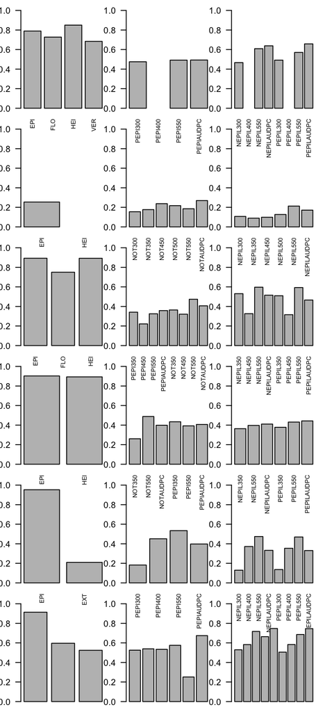

```r
# Start barplot
par(mfrow=c(6,3))
par(mar=c(1,2,1,0))

# Cappelles 2013
dat=as.data.frame(herit_CAP13)
colnames(dat)=gsub("CAP13_","", colnames(dat))
a=as.matrix( dat[1,c("EPI","FLO","HEI","VER")] )
barplot(a, xlab="", col="grey", cex.names=0.7, las=2, ylim=c(0,1), ylab="CAPPELLE 2013" )
b=as.matrix( dat[1,c("PEPI300","PEPI400","PEPI550","PEPIAUDPC")] )
barplot(b, xlab="", col="grey", cex.names=0.7, las=2, ylim=c(0,1) )
c=as.matrix( dat[1,c("NEPIL300","NEPIL400","NEPIL550","NEPILAUDPC","PEPIL300","PEPIL400","PEPIL550","PEPILAUDPC")] )
barplot(c, xlab="", col="grey", cex.names=0.7, las=2, ylim=c(0,1) )

# Grisolles 2011
dat=as.data.frame(herit_GRI11)
colnames(dat)=gsub("GRI11_","", colnames(dat))
a=as.matrix( dat[1,c("EPI","HEI")] )
barplot(a, xlab="", col="grey", cex.names=0.7, las=2, ylim=c(0,1), ylab="GRISOLLES 2011" )
b=as.matrix( dat[1,c("NOT300","NOT350","NOT450","NOT500","NOT550","NOTAUDPC")] )
barplot(b, xlab="", col="grey", cex.names=0.7, las=2, ylim=c(0,1) )
c=as.matrix( dat[1,c("NEPIL300","NEPIL350","NEPIL450","NEPIL500","NEPIL550","NEPILAUDPC")] )
barplot(c, xlab="", col="grey", cex.names=0.7, las=2, ylim=c(0,1) )

# Grisolles 2013
dat=as.data.frame(herit_GRI13)
colnames(dat)=gsub("GRI13_","", colnames(dat))
a=as.matrix( dat[1,c("EPI","FLO","HEI")] )
barplot(a, xlab="", col="grey", cex.names=0.7, las=2, ylim=c(0,1), ylab="GRISOLLES 2013" )
b=as.matrix( dat[1,c("PEPI350","PEPI450","PEPI550","PEPIAUDPC","NOT350", "NOT450", "NOT550", "NOTAUDPC")] )
barplot(b, xlab="", col="grey", cex.names=0.7, las=2, ylim=c(0,1) )
c=as.matrix( dat[1,c("NEPIL350","NEPIL450","NEPIL550","NEPILAUDPC","PEPIL350","PEPIL450","PEPIL550","PEPILAUDPC")] )
barplot(c, xlab="", col="grey", cex.names=0.7, las=2, ylim=c(0,1) )

# Grisolles 2015
dat=as.data.frame(herit_GRI15)
colnames(dat)=gsub("GRI15_","", colnames(dat))
a=as.matrix( dat[1,c("EPI","HEI")] )
barplot(a, xlab="", col="grey", cex.names=0.7, las=2, ylim=c(0,1) , ylab="GRISOLLES 2015")
b=as.matrix( dat[1,c("NOT350","NOT550","NOTAUDPC","PEPI350","PEPI550", "PEPIAUDPC")] )
barplot(b, xlab="", col="grey", cex.names=0.7, las=2, ylim=c(0,1) )
c=as.matrix( dat[1,c("NEPIL350","NEPIL550","NEPILAUDPC","PEPIL350","PEPIL550","PEPILAUDPC")] )
barplot(c, xlab="", col="grey", cex.names=0.7, las=2, ylim=c(0,1) )

# Lectoure 2014
dat=as.data.frame(herit_LEC14)
colnames(dat)=gsub("LEC14_","", colnames(dat))
a=as.matrix( dat[1,c("EPI","EXT")] )
barplot(a, xlab="", col="grey", cex.names=0.7, las=2, ylim=c(0,1) , ylab="LECTOURE 2014")
b=as.matrix( dat[1,c("PEPI300","PEPI400","PEPI550","PEPIAUDPC")] )
barplot(b, xlab="", col="grey", cex.names=0.7, las=2, ylim=c(0,1) )
c=as.matrix( dat[1,c("NEPIL300","NEPIL400", "NEPIL550","NEPILAUDPC","PEPIL300","PEPIL400","PEPIL550","PEPILAUDPC")] )
barplot(c, xlab="", col="grey", cex.names=0.7, las=2, ylim=c(0,1) )

# Pas de rep pour Montbequi

# Montbartier 14
dat=as.data.frame(herit_BAR14)
colnames(dat)=gsub("BAR14_","", colnames(dat))
a=as.matrix( dat[1,c("EPI","ROUY","EXT")] )
barplot(a, xlab="", col="grey", cex.names=0.7, las=2, ylim=c(0,1) , ylab="LECTOURE 2014")
b=as.matrix( dat[1,c("NOT600", "PEPI350","PEPI400","PEPI550","PEPI600","PEPIAUDPC")] )
barplot(b, xlab="", col="grey", cex.names=0.7, las=2, ylim=c(0,1) )
c=as.matrix( dat[1,c("NEPIL300","NEPIL400", "NEPIL550","NEPIL600","NEPILAUDPC","PEPIL300","PEPIL400","PEPIL600","PEPILAUDPC")] )
barplot(c, xlab="", col="grey", cex.names=0.7, las=2, ylim=c(0,1) )
```

## Rough values

*Cappelles 2013*

| CAP13_EPI | CAP13_FLO | CAP13_HEI | CAP13_VER | CAP13_INO | CAP13_INO2 | CAP13_PEPI300 | CAP13_PEPI400 | CAP13_PEPI550 | CAP13_PEPIAUDPC | CAP13_NEPIL300 | CAP13_NEPIL400 | CAP13_NEPIL550 | CAP13_NEPILAUDPC | CAP13_PEPIL300 | CAP13_PEPIL400 | CAP13_PEPIL550 | CAP13_PEPILAUDPC | CAP13_DON |
| --- | --- | --- | --- | --- | --- | --- | --- | --- | --- | --- | --- | --- | --- | --- | --- | --- | --- | --- |
| 0.79 | 0.73 | 0.85 | 0.68 | 0.79 | 0.82 | 0.48 |  | 0.49 | 0.49 | 0.47 |  | 0.61 | 0.64 | 0.49 |  | 0.57 | 0.66 | 0.493549 |
| 0.55 | 0.36 | 0.85 | 0.68 | 0.89 | 0.36 | 0.43 |  | 0.44 | 0.42 | 0.45 |  | 0.50 | 0.57 | 0.48 |  | 0.46 | 0.61 | NA |

*Grisolles 2011*

| GRI11_HEI | GRI11_EPI | GRI11_NOT300 | GRI11_NOT350 | GRI11_NOT450 | GRI11_NOT500 | GRI11_NOT550 | GRI11_NOTAUDPC | GRI11_NEPIL300 | GRI11_NEPIL350 | GRI11_NEPIL450 | GRI11_NEPIL500 | GRI11_NEPIL550 | GRI11_NEPILAUDPC | GRI11_NANT |
| --- | --- | --- | --- | --- | --- | --- | --- | --- | --- | --- | --- | --- | --- | --- |
| NA | 0.254154 | 0.154995 | 0.176831 | 0.237493 | 0.217175 | 0.185623 | 0.26935 | 0.106879 | 0.089302 | 0.098564 | 0.127013 | 0.212703 | 0.171407 | NA |

*Grisolles 2013*

| GRI13_EPI | GRI13_FLO | GRI13_HEI | GRI13_INO | GRI13_PEPI350 | GRI13_PEPI450 | GRI13_PEPI550 | GRI13_PEPIAUDPC | GRI13_NEPIL350 | GRI13_NEPIL450 | GRI13_NEPIL550 | GRI13_NEPILAUDPC | GRI13_PEPIL350 | GRI13_PEPIL450 | GRI13_PEPIL550 | GRI13_PEPILAUDPC | GRI13_NOT350 | GRI13_NOT450 | GRI13_NOT550 | GRI13_NOTAUDPC | GRI13_DON |
| --- | --- | --- | --- | --- | --- | --- | --- | --- | --- | --- | --- | --- | --- | --- | --- | --- | --- | --- | --- | --- |
| 0.89 | 0.75 | 0.89 | 0.80 | 0.34 | 0.22 | 0.33 | 0.36 | 0.53 | 0.33 | 0.60 | 0.52 | 0.51 | 0.32 | 0.59 | 0.47 | 0.36 | 0.32 | 0.47 | 0.41 | 0.34827 |
| 0.69 | 0.20 | 0.90 | 0.85 | 0.32 | 0.18 | 0.32 | 0.33 | 0.54 | 0.33 | 0.60 | 0.52 | 0.51 | 0.32 | 0.59 | 0.47 | 0.34 | 0.32 | 0.48 | 0.40 | NA |

*Grisolles 2015*

| GRI15_EPI | GRI15_HEI | GRI15_NOT350 | GRI15_NOT550 | GRI15_NOTAUDPC | GRI15_PEPI350 | GRI15_PEPI550 | GRI15_PEPIAUDPC | GRI15_NEPIL350 | GRI15_NEPIL550 | GRI15_NEPILAUDPC | GRI15_PEPIL350 | GRI15_PEPIL550 | GRI15_PEPILAUDPC |
| --- | --- | --- | --- | --- | --- | --- | --- | --- | --- | --- | --- | --- | --- |
| 0.90 | 0.89 | 0.26 | 0.49 | 0.40 | 0.43 | 0.39 | 0.41 | 0.36 | 0.40 | 0.41 | 0.38 | 0.43 | 0.44 |
| 0.26 | 0.88 | 0.27 | 0.50 | 0.42 | 0.43 | 0.40 | 0.41 | 0.36 | 0.41 | 0.42 | 0.37 | 0.44 | 0.45 |

*Lectoure 2014*

| LEC14_EPI | LEC14_EXT | LEC14_INO | LEC14_PEPI300 | LEC14_PEPI400 | LEC14_PEPI550 | LEC14_PEPIAUDPC | LEC14_NEPIL300 | LEC14_NEPIL400 | LEC14_NEPIL550 | LEC14_NEPILAUDPC | LEC14_PEPIL300 | LEC14_PEPIL400 | LEC14_PEPIL550 | LEC14_PEPILAUDPC |
| --- | --- | --- | --- | --- | --- | --- | --- | --- | --- | --- | --- | --- | --- | --- |
| 0.95 | 0.21 | 0.92 | 0.18 | 0.45 | 0.53 | 0.40 | 0.13 | 0.37 | 0.47 | 0.33 | 0.14 | 0.35 | 0.47 | 0.33 |
| 0.57 | 0.21 | 0.96 | 0.18 | 0.41 | 0.48 | 0.36 | 0.13 | 0.34 | 0.43 | 0.30 | 0.13 | 0.31 | 0.41 | 0.29 |

*Montbequi 2011* Pas de rep?

*Montbartier 2014*

| BAR14_EPI | BAR14_ROUY | BAR14_NOT600 | BAR14_NEPIL | BAR14_EXT | BAR14_PEPI350 | BAR14_PEPI400 | BAR14_PEPI550 | BAR14_PEPI600 | BAR14_PEPIAUDPC | BAR14_NEPIL300 | BAR14_NEPIL400 | BAR14_NEPIL550 | BAR14_NEPIL600 | BAR14_NEPILAUDPC | BAR14_PEPIL300 | BAR14_PEPIL400 | BAR14_PEPIL550 | BAR14_PEPIL600 | BAR14_PEPILAUDPC |
| --- | --- | --- | --- | --- | --- | --- | --- | --- | --- | --- | --- | --- | --- | --- | --- | --- | --- | --- | --- |
| 0.91 | 0.60 | 0.53 | 0.79 | 0.52 | 0.54 | 0.53 | 0.58 | 0.25 | 0.67 | 0.53 | 0.58 | 0.72 | 0.66 | 0.75 | 0.51 | 0.58 | 0.70 | 0.69 | 0.75 |
| 0.67 | 0.59 | 0.38 | 0.72 | 0.52 | 0.51 | 0.53 | 0.57 | 0.25 | 0.67 | 0.53 | 0.58 | 0.71 | 0.66 | 0.75 | 0.50 | 0.58 | 0.70 | 0.68 | 0.74 |

## Effect of Innoculation date

[output not shown]

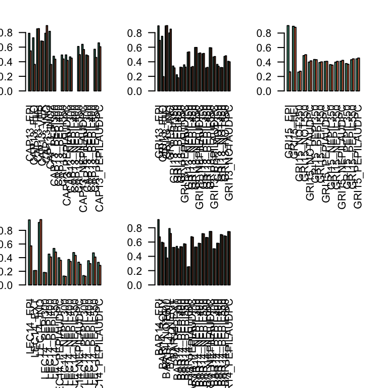

```r
# Show
par(mfrow=c(2,3), mar=c(8,2,2,2))
my_list=list(herit_CAP13[,c(1:18)], herit_GRI13[,-21] , herit_GRI15, herit_LEC14, herit_BAR14)
lapply(my_list, function(x){ barplot(as.matrix(x),beside=T, las=2, col=my_colors[c(1,2)] )}  )
```

## Conclusion

# 6/ Output phenotype table

Now we need to merge all these data together for further study (QTL). We create the file **phenotypage_all_fusa.csv** that will be used for QTL analyses.

```r
# Concatenate every file
FINAL=my_indiv
for(i in list(CAP13_clean, CAP13_DON_clean, GRI11_clean, GRI13_clean, GRI13_DON_clean, GRI15_clean, LEC14_clean, LEC14_DON_clean, BEQ11_clean, BAR14_clean)){
  #print(head(colnames(i)))
  FINAL=merge(FINAL, i, by.x=1, by.y=1, all.x=T)
   }
colnames(FINAL)[1]="geno"

# I remove the variable concerning innoculation date:
FINAL=FINAL[ , -grep( "INO", colnames(FINAL) ) ]
write.table(FINAL, file="/Users/yan/Dropbox/Publi_Fusariose/ANALYSIS_REPRO/DATA/PHENOTYPE/phenotypage_all_fusa.csv", quote=F, row.names=F, col.names=T, sep=";")
```

Number of variable available:

```r
dim(FINAL)
```

```
## [1] 199 316
```

Check I have 0 in names

```r
#FINAL$geno
```

Do I have duplicate genotypes?

```r
table(FINAL$geno)[table(FINAL$geno)>1]
```

```
## named integer(0)
```